# Writing narratives with data: An introduction to ggplot!

#### Changing the final look of the plot

Now we have pretty much all of the elements in place! The last things we will do will focus on the look of the plot.

First, we want to move the legend to the upper lefthand corner of the plot.

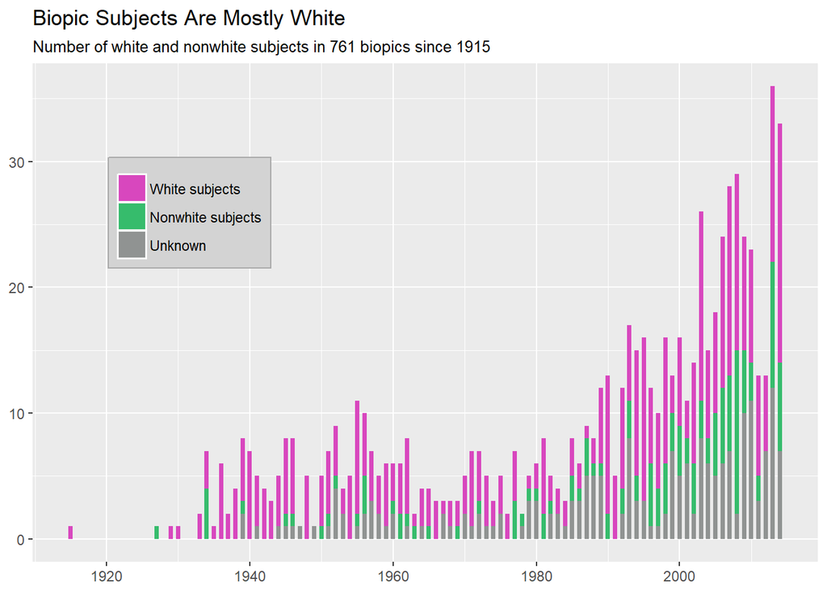

```r
ggplot(data = race_plot, aes(x= year_release, y = total)) +
  geom_bar(aes(fill = race_plotting), stat = "identity", width = 0.6) +
  labs(title = "Biopic Subjects Are Mostly White",
       subtitle = "Number of white and nonwhite subjects in 761 biopics since 1915",
       x = NULL,
       y = NULL) +
  scale_fill_manual(values = c("#d847be", "#36bc6c", "#909392")) +
  theme(legend.position = c(.2,.7),
        legend.background = element_rect(fill="lightgray",
                                         size=0.5,
                                         linetype="solid",
                                         colour ="darkgray"),
        legend.title = element_blank())
```

One nice trick with ggplot is the package `ggthemes`. It has preloaded templates for different popular press outlets and plotting tools. Lucky for us, there’s a `fivethirtyeight` theme. We’ll use that to make our lives a little easier, but you could style it the same way with your own `ggplot` code! In this case, though, why reinvent the wheel?

Notice in the code below that `theme_fivethirtyeight` has to come before our `theme` arguments. We want to override a few defaults from `ggtheme` and `R` executes code sequentially. If you write them in the other order, you’ll be overriding our overrides.

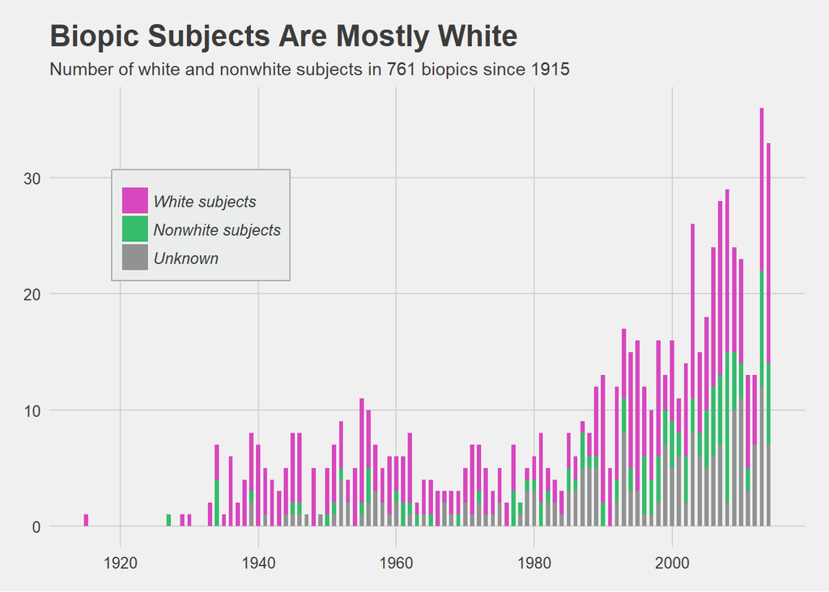

```r
ggplot(data = race_plot, aes(x= year_release, y = total)) +
  geom_bar(aes(fill = race_plotting), stat = "identity", width = 0.6) +
  labs(title = "Biopic Subjects Are Mostly White",
       subtitle = "Number of white and nonwhite subjects in 761 biopics since 1915",
       x = NULL,
       y = NULL) +
  scale_fill_manual(values = c("#d847be", "#36bc6c", "#909392")) +
  theme_fivethirtyeight() +
  theme(legend.position = c(.2,.7),
        legend.background = element_rect(fill="#eaedeb",
                                         size=0.5,
                                         linetype="solid",
                                         colour ="darkgray"),
        legend.direction = "vertical",
        legend.title = element_blank(),
        legend.text = element_text(face = "italic"))
```

Ta-da! Done! That wasn’t so bad, right? On to our next viz!

## Looking at gender

We will follow pretty similar steps for our next viz, so I’m going to move a little more quickly through the steps. Refer back to the previous explanations if you get stuck, or feel free to shout out questions!

First, take a look at our goal for this part of the activity!

[figure not shown]

Take a minute to think about how the variables are being mapped to different aesthetics in this plot. What is the x-axis? Y-axis? Color?

#### Setting up our data

```r
gender_plotting <- biopics %>%
  group_by(subject_sex,year_release) %>%
  summarize(total = n()) # this is going to calculate the number of biopics about men and women separately for each year
```

#### Setting up our axes

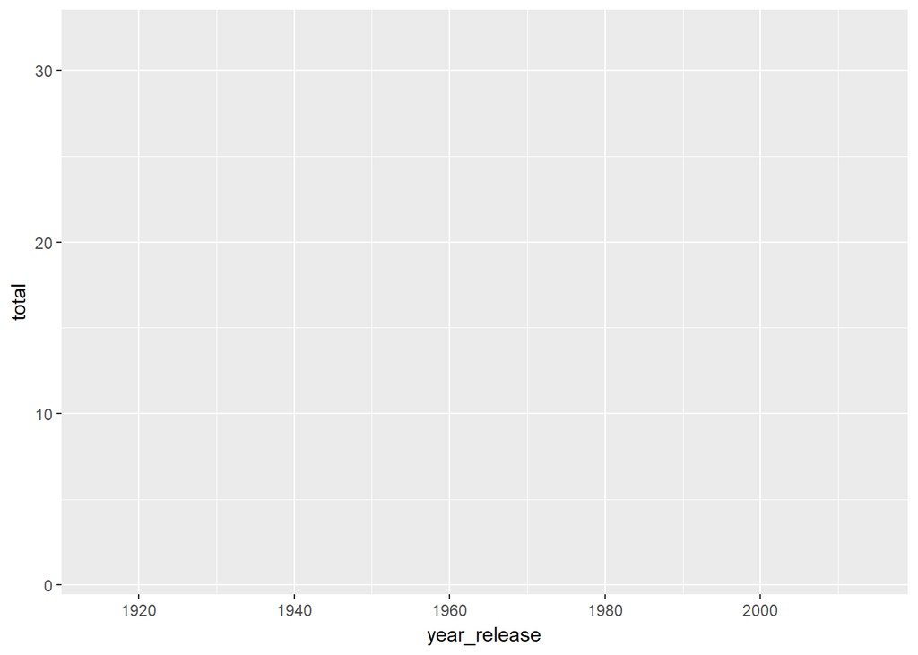

```r
ggplot(data = gender_plotting, aes(x = year_release, y = total))
```

#### Lets add our `geom`!

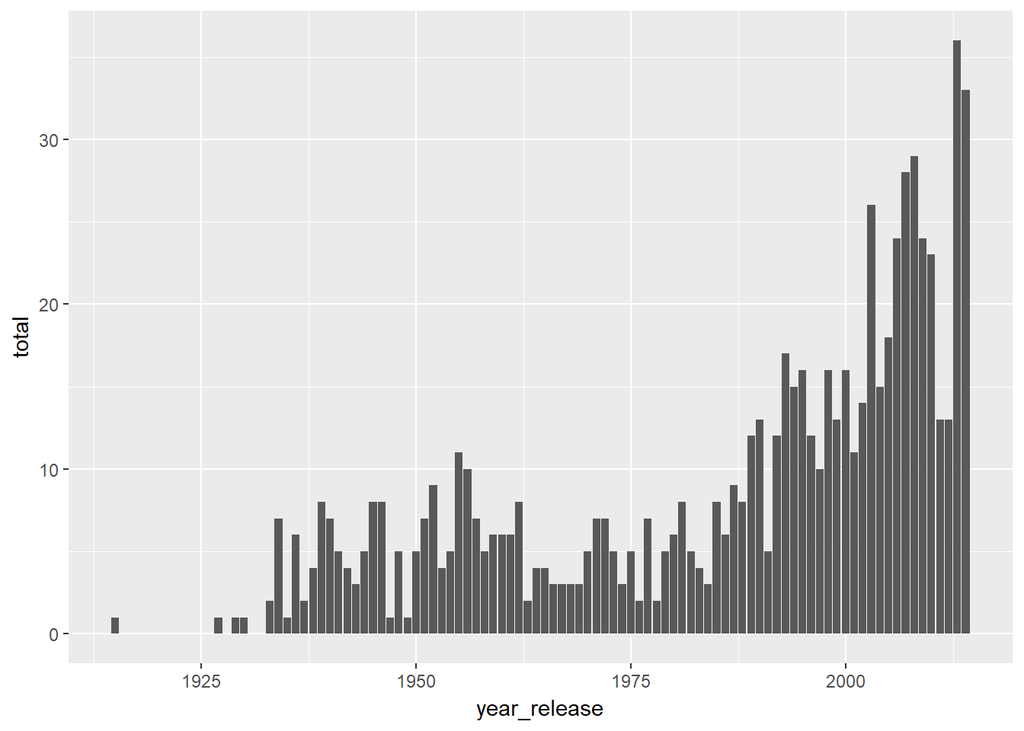

```r
ggplot(data = gender_plotting, aes(x = year_release, y = total)) +
  geom_bar(stat = "identity") # don't forget stat = "identity"
```

#### Adding colors and a legend

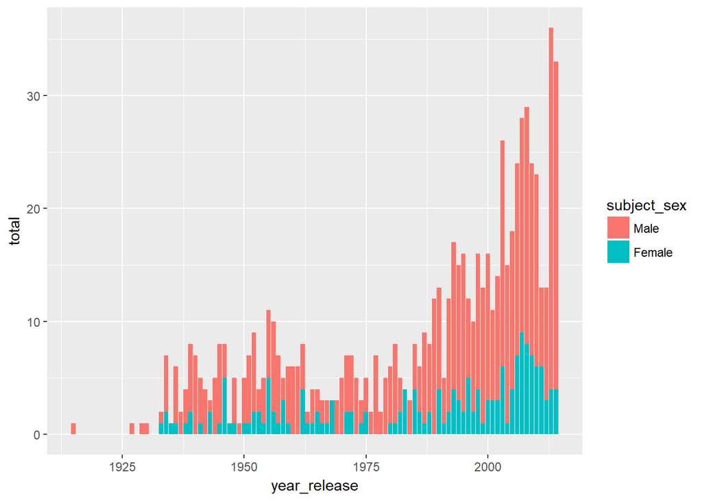

```r
# changing the stacking order

gender_plotting$subject_sex <- factor(gender_plotting$subject_sex, levels = c("Male", "Female"))


ggplot(data = gender_plotting, aes(x = year_release, y = total, fill = subject_sex)) +
  geom_bar(stat = "identity")
```

We can already see a pretty clear pattern in the data and we’ve done the hard part of plotting! Now let’s make it a little prettier. We will use a lot of the same code from our last plot for the design aspects!

#### Design

In this section, I’ll introduce saving a plot as a variable so that we don’t have to type the same thing over and over.

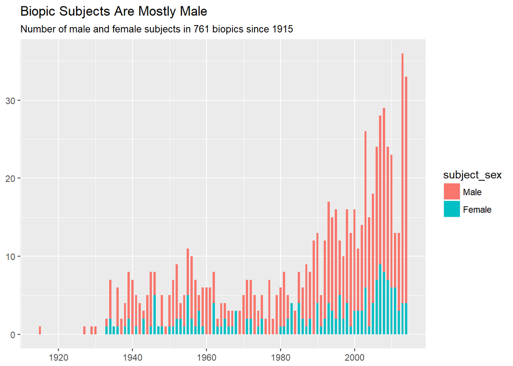

```r
# I again changed the width of the bars here

g <- ggplot(data = gender_plotting, aes(x = year_release, y = total, fill = subject_sex)) +
  geom_bar(stat = "identity", width = 0.6) +
  labs(title = "Biopic Subjects Are Mostly Male",
       subtitle = "Number of male and female subjects in 761 biopics since 1915",
       x = NULL,
       y = NULL)

g
```

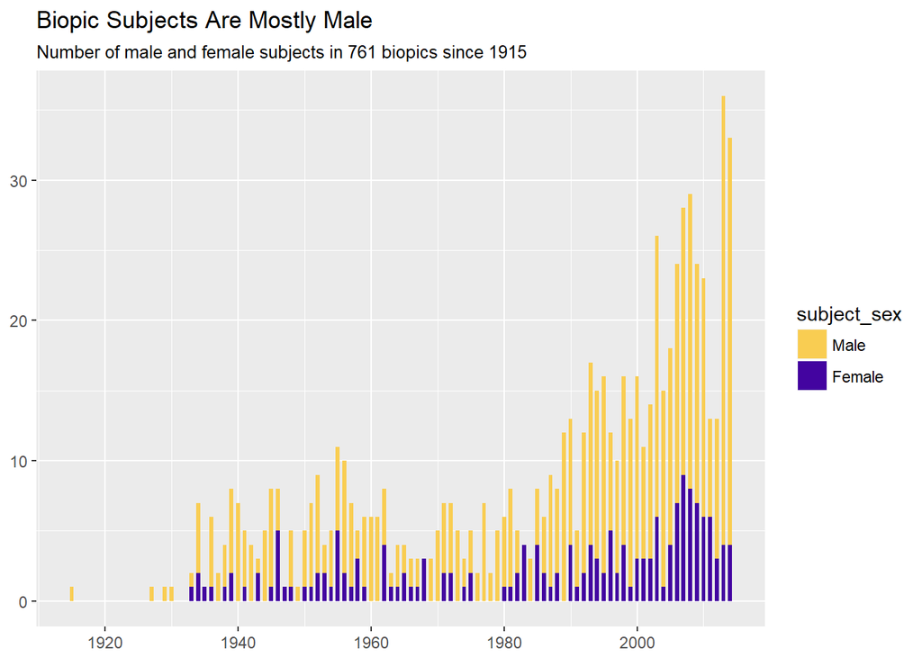

```r
# add the right colors now!

g <- g +
  scale_fill_manual(values = c("#f9cd52", "#4304a0"))

g
```

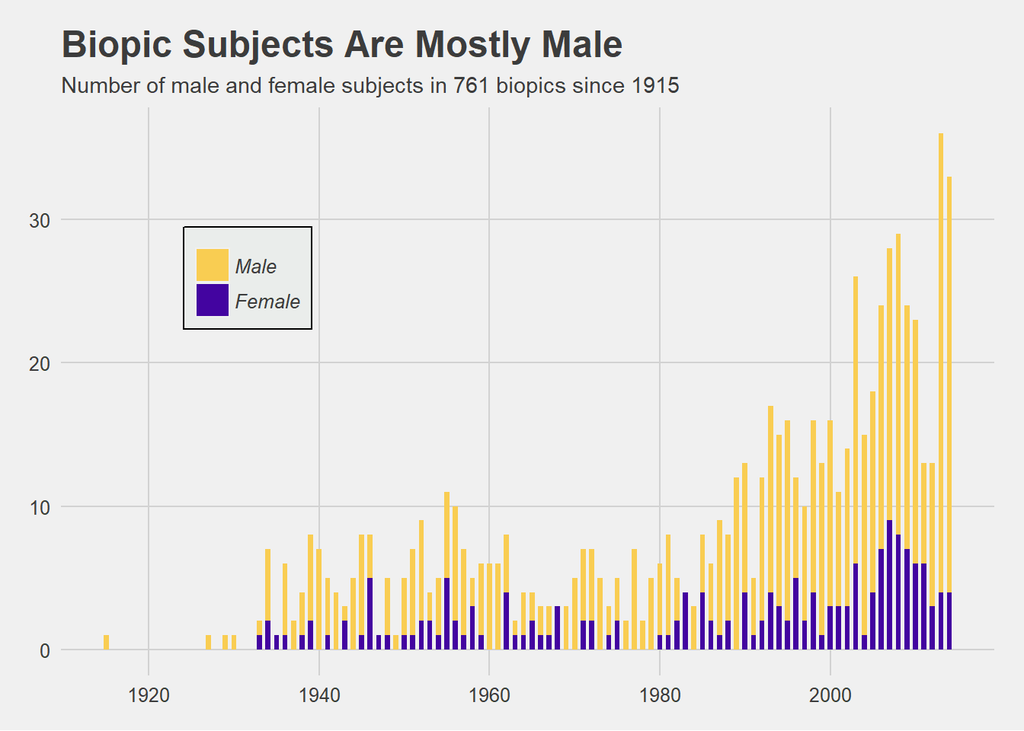

```r
# format the legend in a better way and add the fivethirtyeight theme!
g <- g +
  theme_fivethirtyeight() +
  theme(legend.position = c(.2,.7),
        legend.background = element_rect(fill="#eaedeb",
                                         size=0.5,
                                         linetype="solid",
                                         colour ="black"),

        legend.direction = "vertical",
        legend.title = element_blank(),
        legend.text = element_text(face = "italic"))

g
```

Nice! Now we’ve finished recreating the two graphics from the article, but there are so many others. We’ll walk through creating one more. To combine the previous two graphs (and learn a new feature of ggplot!), we’ll make a plot of gender and race in biopics. The article claims that women of color are by far the most underrepresented, so this plot will allow us to see that pattern.